# R Project Code

Ariana Beloiu

2026-03-05

## Load Packages Needed

```r
library(tidyverse)
library(dplyr)
library(car)
library(ggfortify)
library(vegan)
```

```r
library(ggplot2)
```

## Part A: Univariate statistics with R

### Import the data

```r
perio <- read.csv("PerioData.csv") #open the perio data

head(perio) #inspect the data
```

```
##     id strep prev lepto fuso veil time status pocket deepest   range
## 1 S001  57.4 10.2   0.1  0.0  6.9    1      2    2.7     3.8  middle
## 2 S001  26.0  0.0  25.6  0.0  6.3    2      2    2.7     3.0  middle
## 3 S006  19.0 24.2   4.8  5.7  4.2    1      1    2.5     3.2  middle
## 4 S006  15.2  4.2   0.2  2.6  3.4    2      1    2.4     3.2  middle
## 5 S007  33.2  2.3   7.4  1.3 12.0    1      2    2.4     2.7 shallow
## 6 S007  18.0  0.3  13.6  1.7 13.8    2      2    2.4     2.8 shallow
```

### Make histograms, run qqnorm and qqline of all bacteria and “deepest”

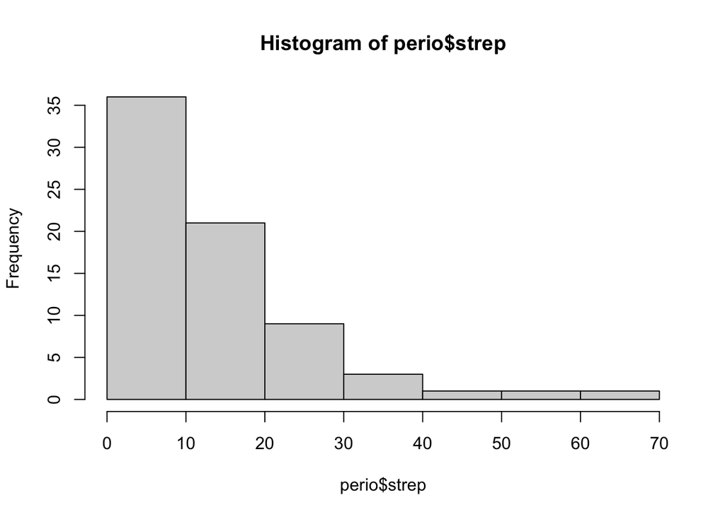

```r
hist(perio$strep) #strep histogram
```

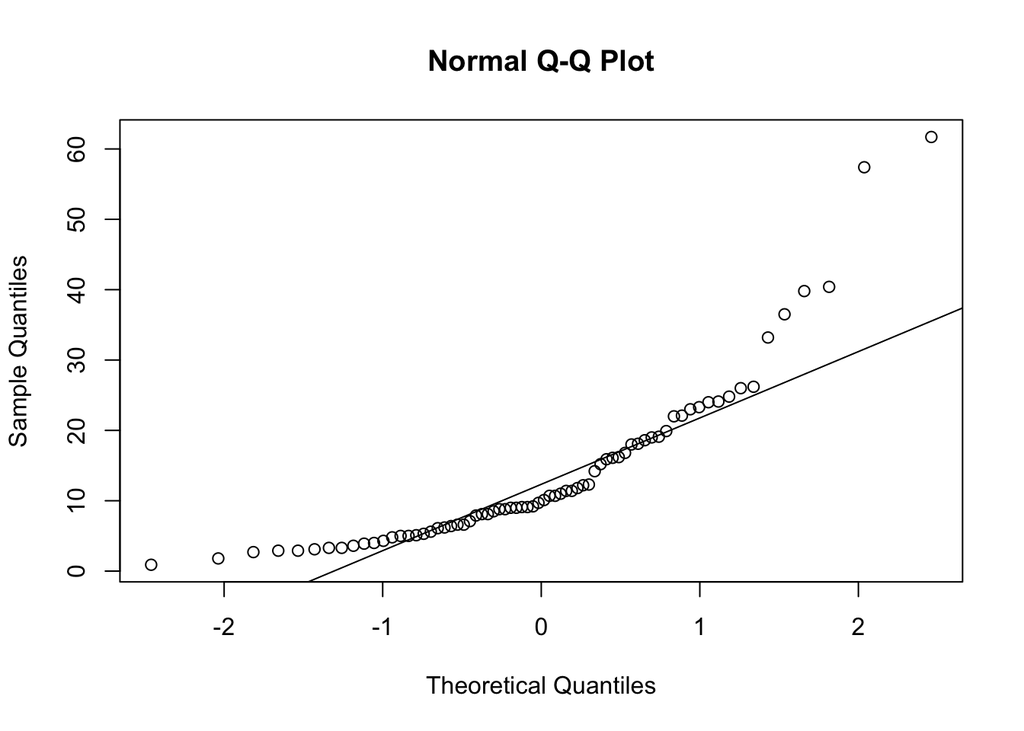

```r
qqnorm(perio$strep) #strep qq-plot
qqline(perio$strep) #adds reference line to the qq-plot
```

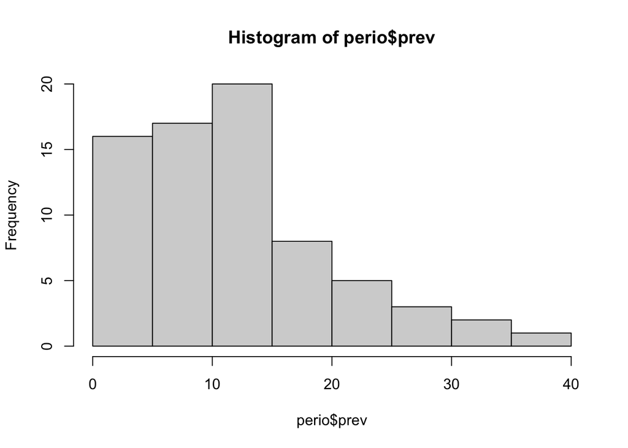

```r
hist(perio$prev) #prev histogram
```

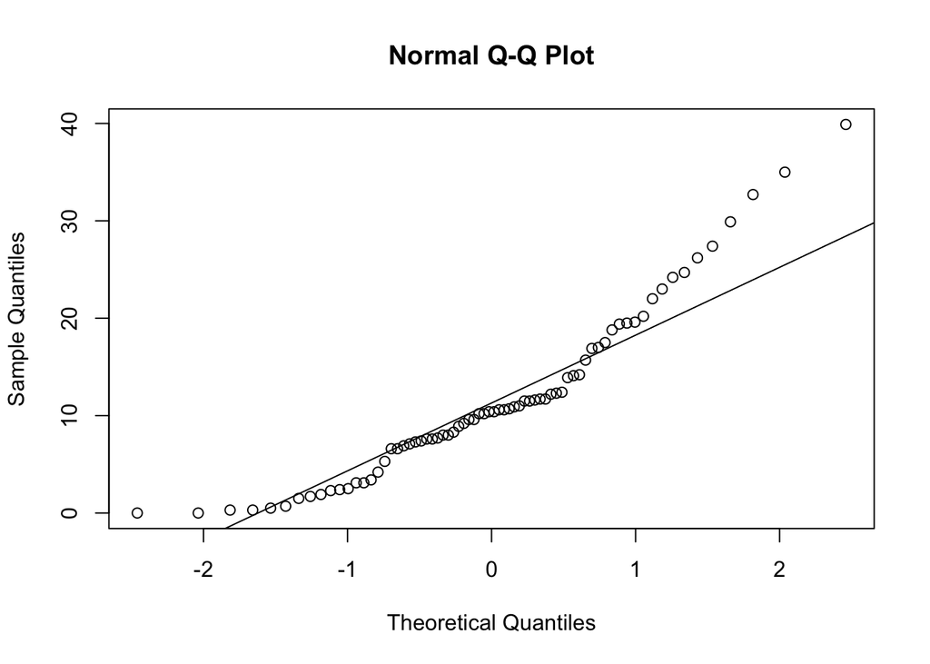

```r
qqnorm(perio$prev) #prev qq-plot
qqline(perio$prev) #adds reference line to the qq-plot
```

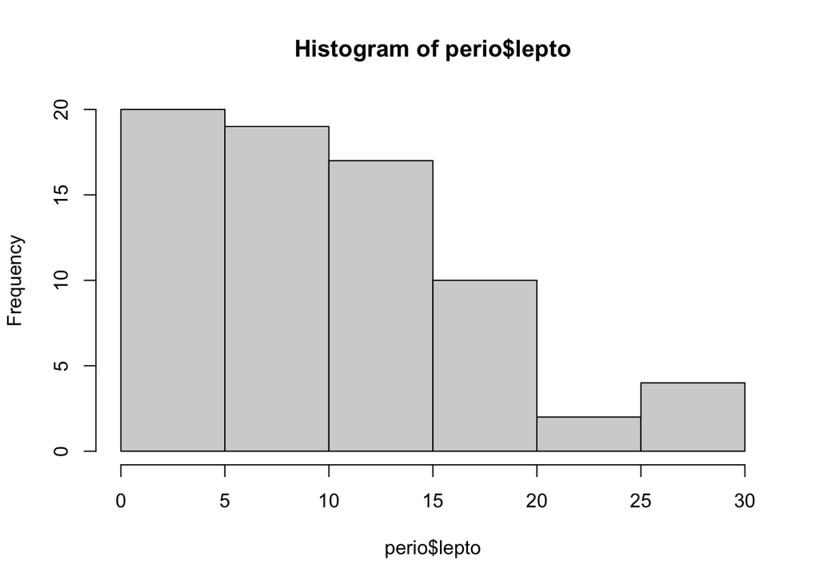

```r
hist(perio$lepto) #lepto histogram
```

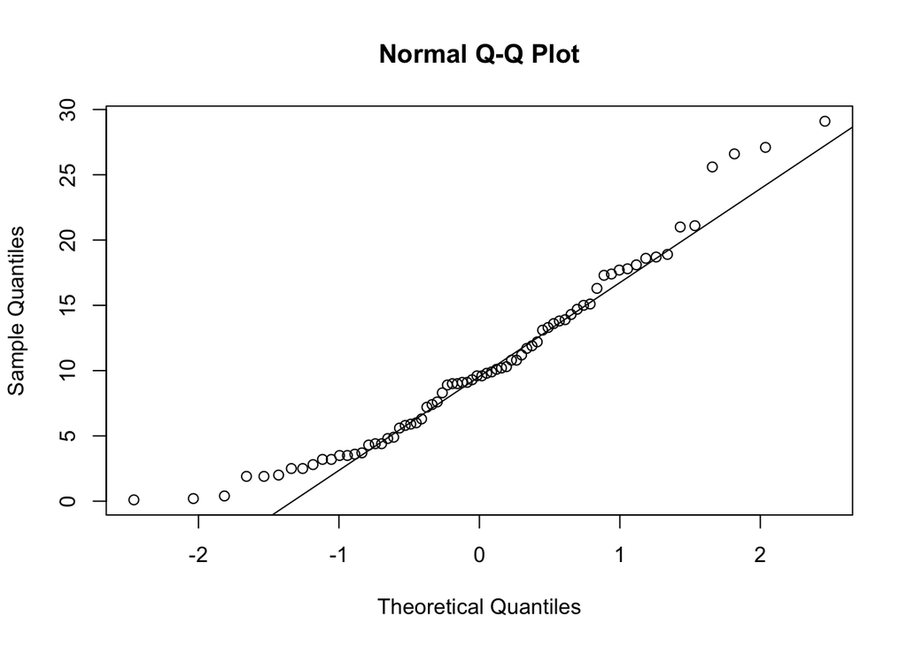

```r
qqnorm(perio$lepto) #lepto qq-plot
qqline(perio$lepto) #adds reference line to the qq-plot
```

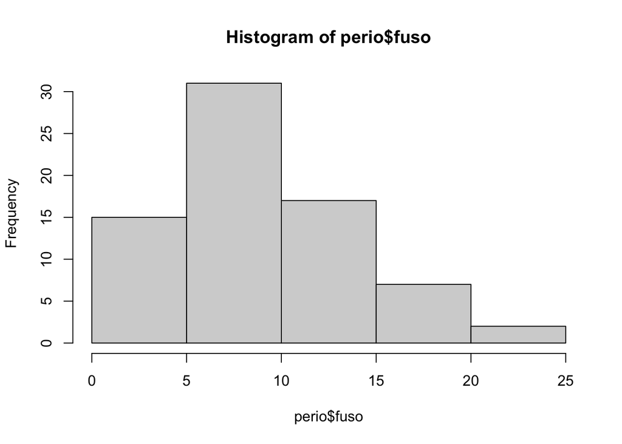

```r
hist(perio$fuso) #fuso histogram
```

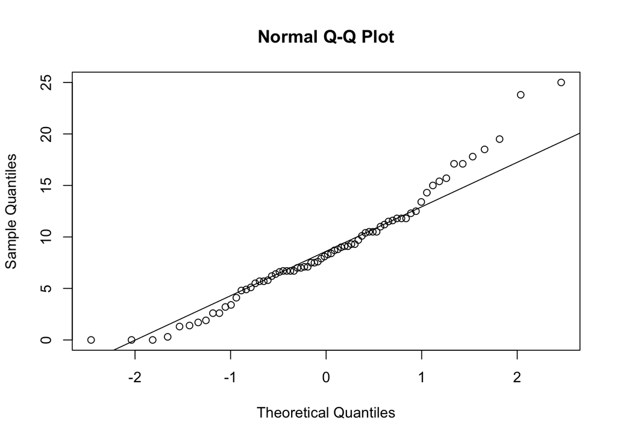

```r
qqnorm(perio$fuso) #fuso qq-plot
qqline(perio$fuso) #adds reference line to the qq-plot
```

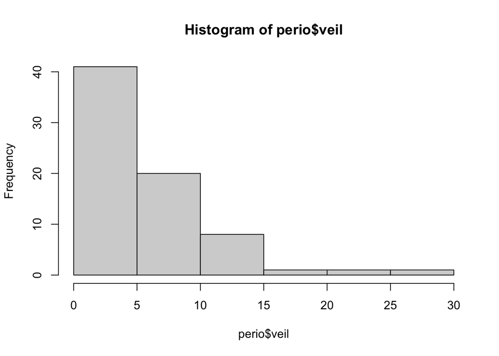

```r
hist(perio$veil) #veil histogram
```

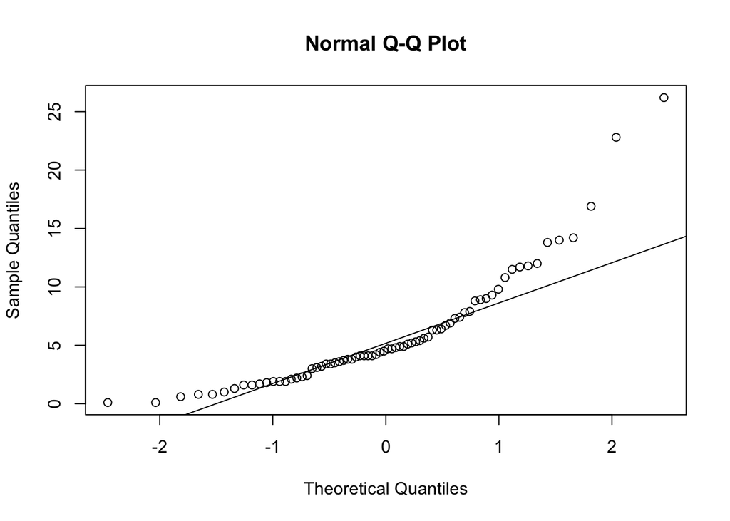

```r
qqnorm(perio$veil) #veil qq-plot
qqline(perio$veil) #adds reference line to the qq-plot
```

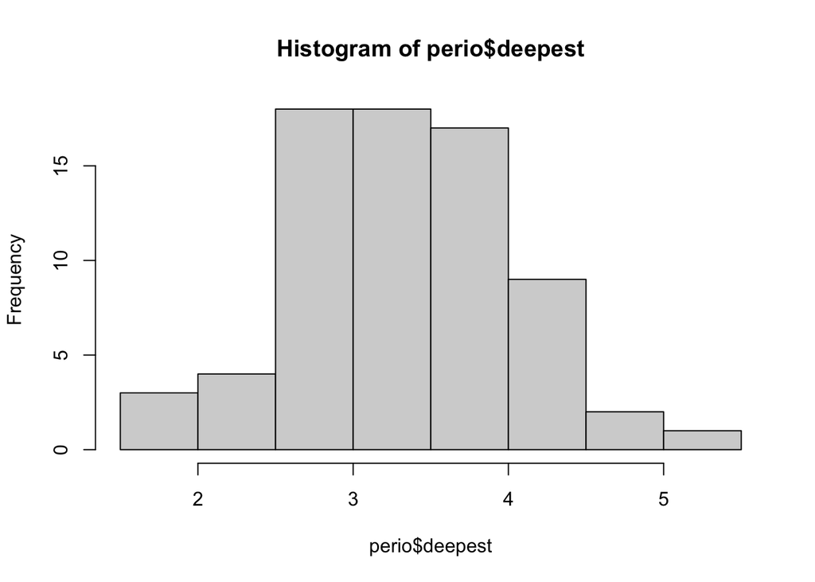

```r
hist(perio$deepest) #"deepest" bacteria histogram
```

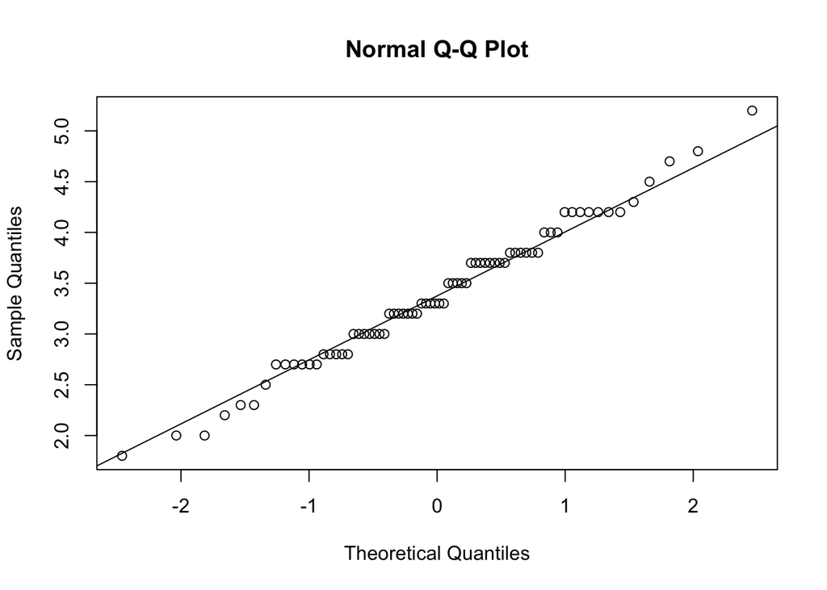

```r
qqnorm(perio$deepest) #"deepest" bacteria qq-plot
qqline(perio$deepest) #adds reference line to the qq-plot
```

The qqplots and histograms for each of the bacteria highlights that they are not following normality and display some skewness. This breaks the assumption of normality. To fix this we must transform the non-normal variables to better fit a normal distribution.

The deepest gum pocket data does approximately follow a normal distribution with minimal skewedness, so no transformation is required.

### Transform variables if non-normal and repeat histogram, qqnorm, qqline on transformed data. For transformations I suggest trying either sqrt() or log()

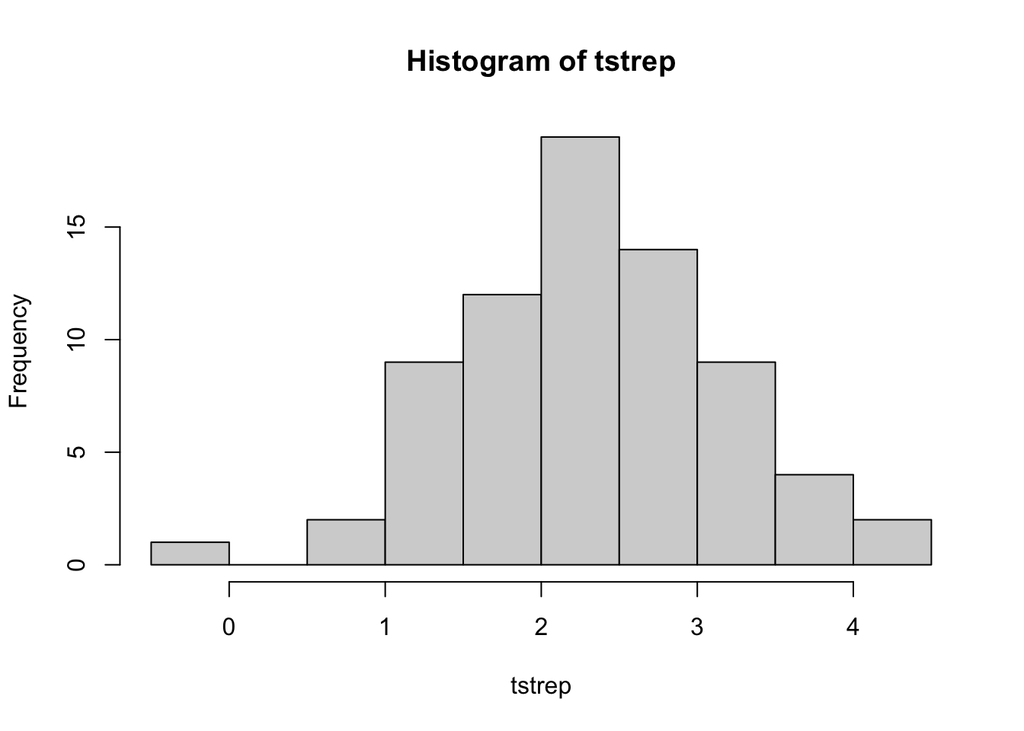

```r
tstrep = log(perio$strep) #log transform strep data
hist(tstrep) #create a histogram for the transformed strep data
```

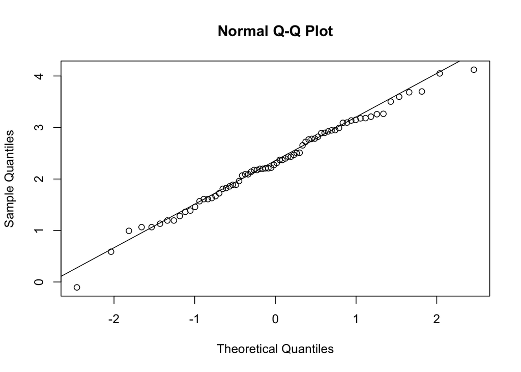

```r
qqnorm(tstrep) #create a qq-plot for the transformed strep data
qqline(tstrep) #add reference line to the qqplot
```

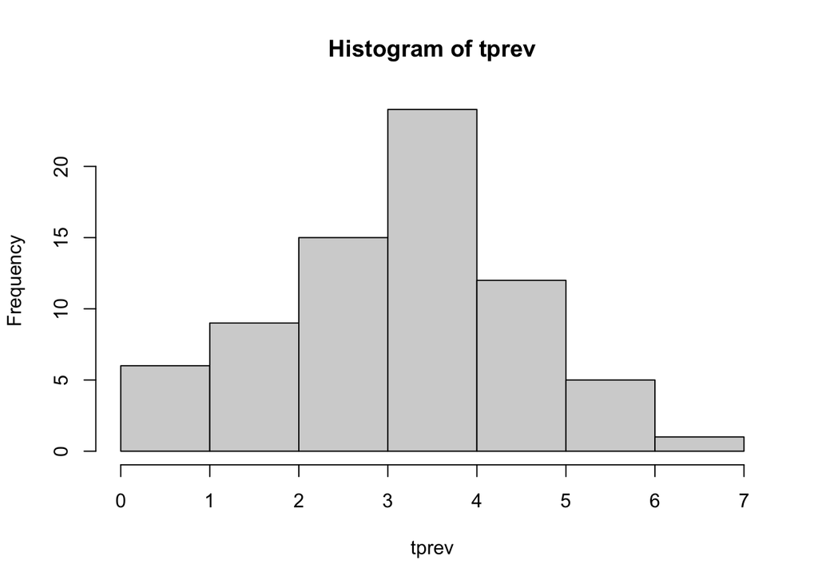

```r
tprev = sqrt(perio$prev) #square root transform prev data
hist(tprev) #create a histogram for the transformed prev data
```

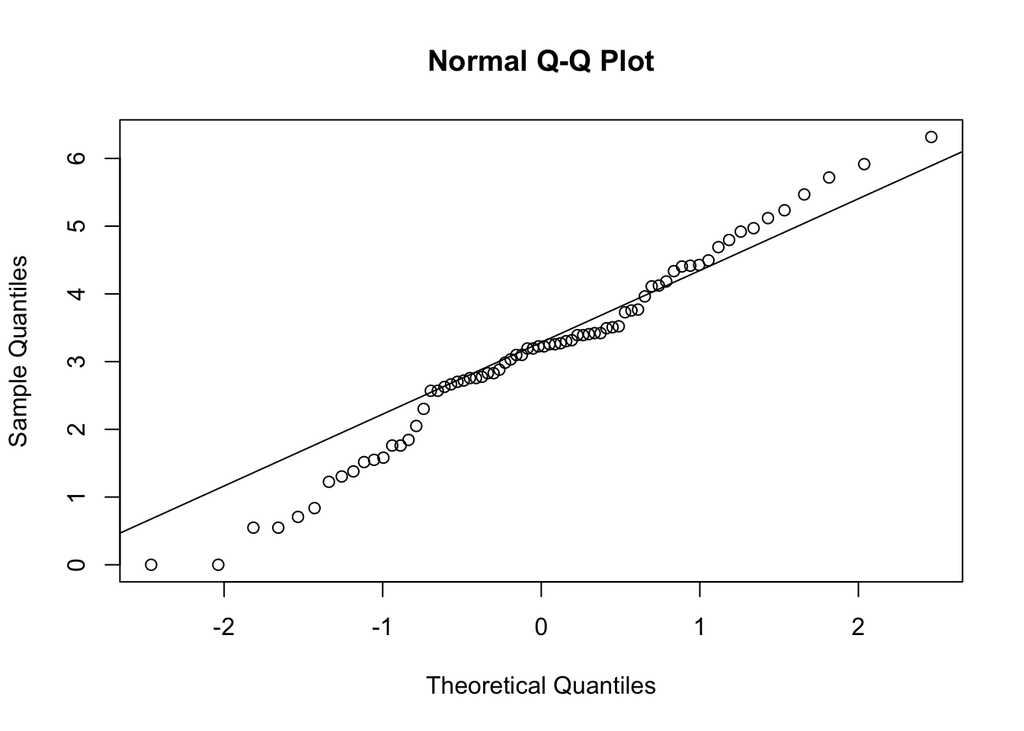

```r
qqnorm(tprev) #create a qq-plot for the transformed prev data
qqline(tprev) #add reference line to the qqplot
```

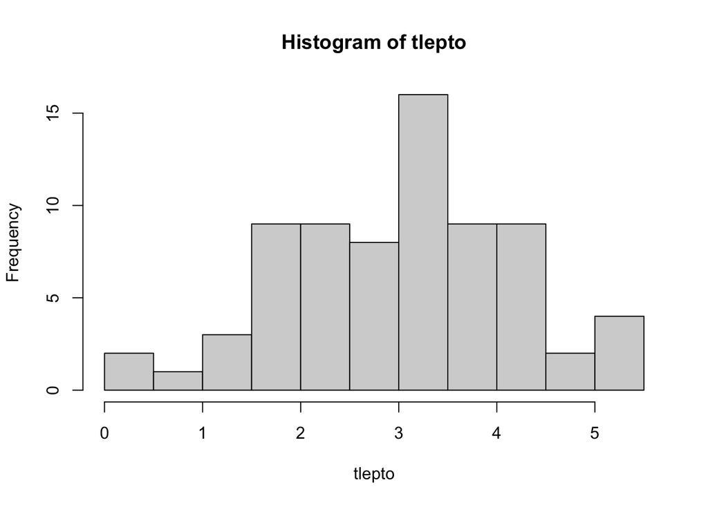

```r
tlepto = sqrt(perio$lepto) #square root transform lepto data
hist(tlepto) #create a histogram for the transformed lepto data
```

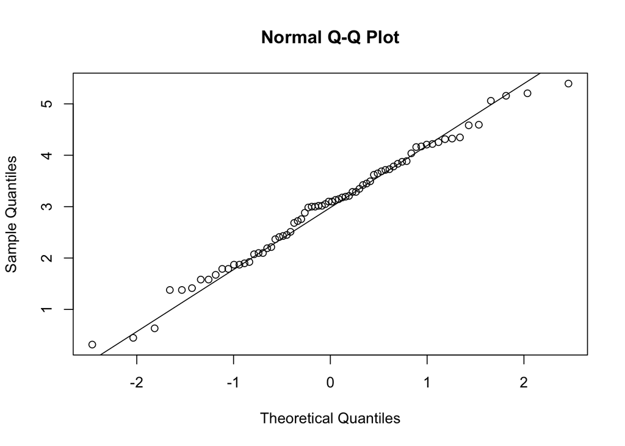

```r
qqnorm(tlepto) #create a qq-plot for the transformed lepto data
qqline(tlepto) #add reference line to the qqplot
```

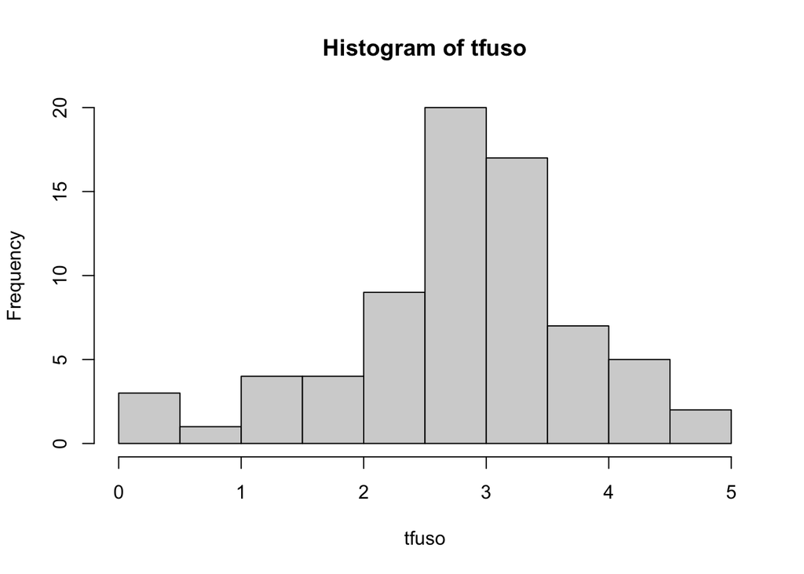

```r
tfuso = sqrt(perio$fuso) #log transform fuso data
hist(tfuso) #create a histogram for the transformed fuso data
```

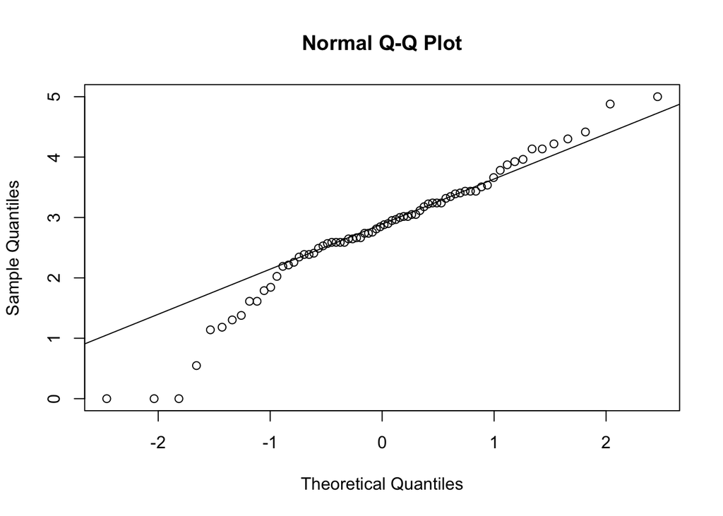

```r
qqnorm(tfuso) #create a qq-plot for the transformed fuso data
qqline(tfuso) #add a reference line to the qqplot
```

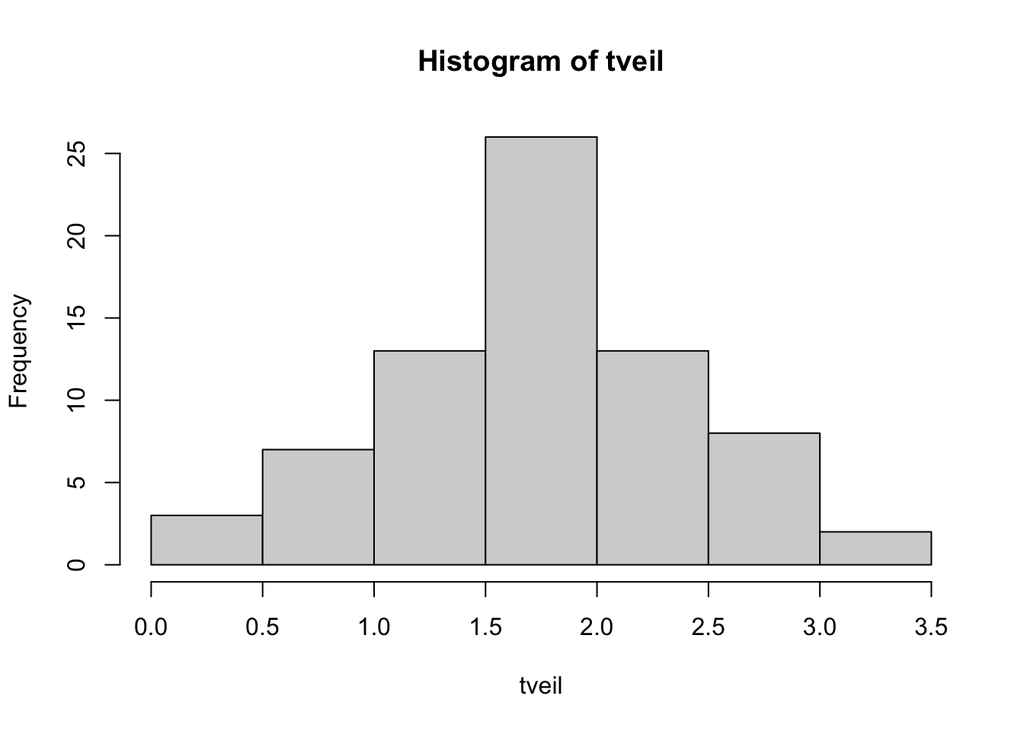

```r
tveil = log(perio$veil + 1) #log + 1 transform veil data
hist(tveil) #create a histogram for the transformed veil data
```

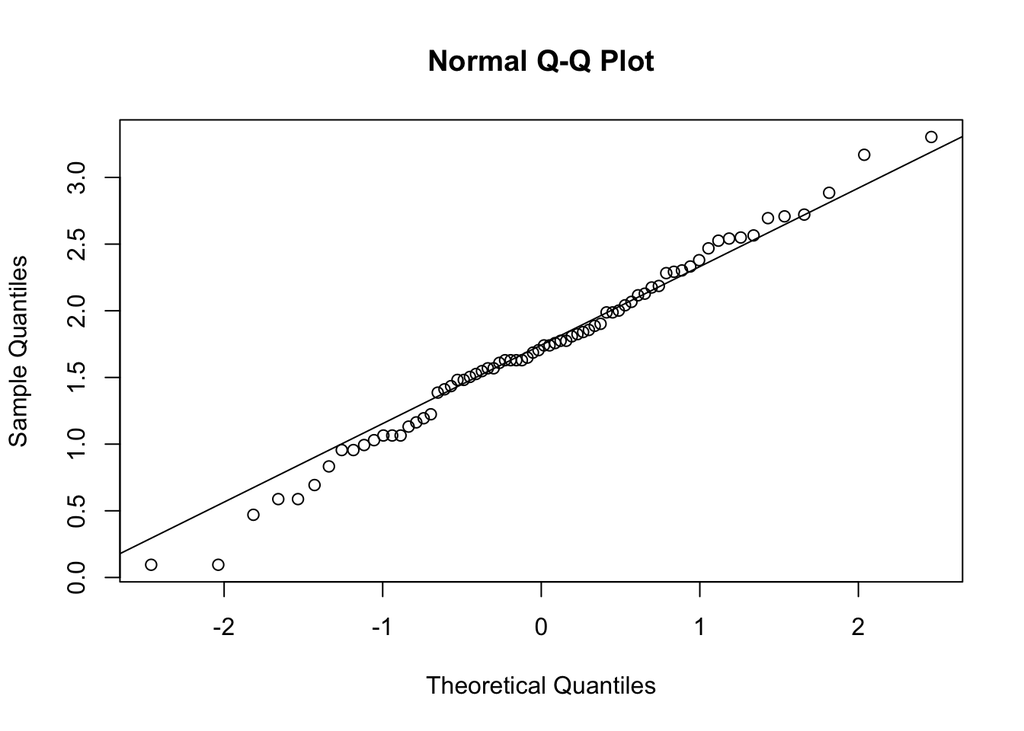

```r
qqnorm(tveil) #create a qq-plot for the transformed veil data
qqline(tveil) #add a reference line to the qqplot
```

### One-way ANOVA and summary and boxplots:

```r
#Lepto by Time

model1 <- aov(tlepto ~ time, data = perio) #create the ANOVA table
model1 #print the anova table
```

```
## Call:
##    aov(formula = tlepto ~ time, data = perio)
##
## Terms:
##                     time Residuals
## Sum of Squares   6.27624  84.45411
## Deg. of Freedom        1        70
##
## Residual standard error: 1.098402
## Estimated effects may be unbalanced
```

```r
summary(model1) #print the summary table
```

```
##             Df Sum Sq Mean Sq F value Pr(>F)
## time         1   6.28   6.276   5.202 0.0256 *
## Residuals   70  84.45   1.206
## ---
## Signif. codes:  0 '***' 0.001 '**' 0.01 '*' 0.05 '.' 0.1 ' ' 1
```

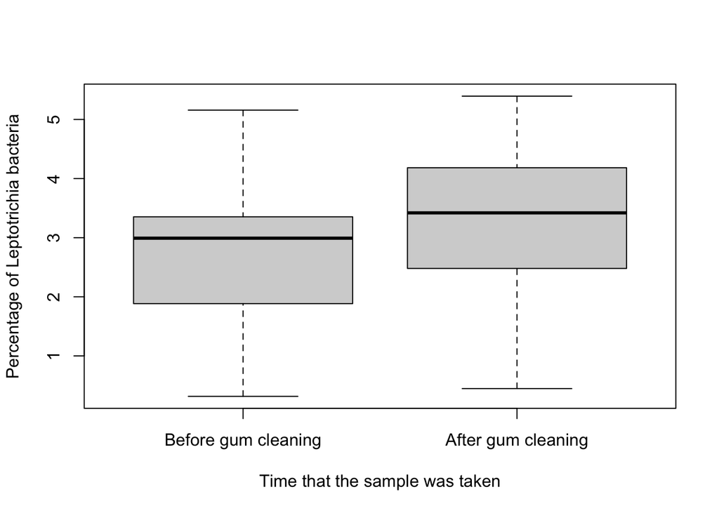

```r
boxplot(tlepto ~ time, data = perio,
        xlab = "Time that the sample was taken",
        ylab = "Percentage of Leptotrichia bacteria",
        names = c("Before gum cleaning", "After gum cleaning")) #create the boxplot
```

After conducting a one-way ANOVA to test whether the percentage of *Leptotrichia* bacteria is affected by the time when gum cleaning occurred, it can be concluded that there were different levels of bacteria based on the time of when gum cleaning occurred (F(1,70), p-value < 0.05).

```r
#Strep by time

model2 <- aov(tstrep ~ time, data = perio) #create the ANOVA table
model2 #print the anova table
```

```
## Call:
##    aov(formula = tstrep ~ time, data = perio)
##
## Terms:
##                     time Residuals
## Sum of Squares   0.60023  48.28858
## Deg. of Freedom        1        70
##
## Residual standard error: 0.8305642
## Estimated effects may be unbalanced
```

```r
summary(model2) #print the summary table
```

```
##             Df Sum Sq Mean Sq F value Pr(>F)
## time         1   0.60  0.6002    0.87  0.354
## Residuals   70  48.29  0.6898
```

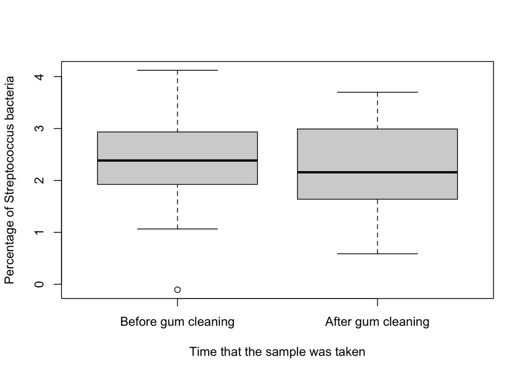

```r
boxplot(tstrep ~ time, data = perio,
        xlab = "Time that the sample was taken",
        ylab = "Percentage of Streptococcus bacteria",
        names = c("Before gum cleaning", "After gum cleaning")) #create the boxplot
```

After conducting a one-way ANOVA to test whether the percentage of *Streptococcus* bacteria is affected by the time when gum cleaning occurred, it can be concluded that there was no significant difference between the levels of bacteria based on the time of when gum cleaning occurred (F(1,70), p-value = 0.354).

### Correlation analysis (cor.test)

```r
cor.test(tstrep, tprev) #conduct a correlation test between Strep and Prev Bacteria
```

```
##
##  Pearson's product-moment correlation
##
## data:  tstrep and tprev
## t = -3.435, df = 70, p-value = 0.001
## alternative hypothesis: true correlation is not equal to 0
## 95 percent confidence interval:
##  -0.5620173 -0.1624218
## sample estimates:
##        cor
## -0.3797993
```

```r
cor.test(tstrep, tfuso) #conduct a correlation test between Strep and Fuso Bacteria
```

```
##
##  Pearson's product-moment correlation
##
## data:  tstrep and tfuso
## t = -4.8827, df = 70, p-value = 6.366e-06
## alternative hypothesis: true correlation is not equal to 0
## 95 percent confidence interval:
##  -0.6587832 -0.3083824
## sample estimates:
##       cor
## -0.504041
```

```r
cor.test(tfuso, tlepto) #conduct a correlation test between Fuso and Lepto Bacteria
```

```
##
##  Pearson's product-moment correlation
##
## data:  tfuso and tlepto
## t = 0.82548, df = 70, p-value = 0.4119
## alternative hypothesis: true correlation is not equal to 0
## 95 percent confidence interval:
##  -0.1365891  0.3225188
## sample estimates:
##        cor
## 0.09818645
```

After conducting correlation tests, it can be concluded that there is a correlation between the percentage of *Streptococcus* bacteria and the *Prevotella* bacteria (p-value < 0.05), as well as a correlation between the percentage *Streptococcus* bacteria and *Fusobacteria* bacteria (p-value < 0.05). However, it can be concluded that there is no correlation between the percentage of *Fusobacteria* bacteria and *Leptotrichia* bacteria (p-value = 0.4119).

### Linear Regressions

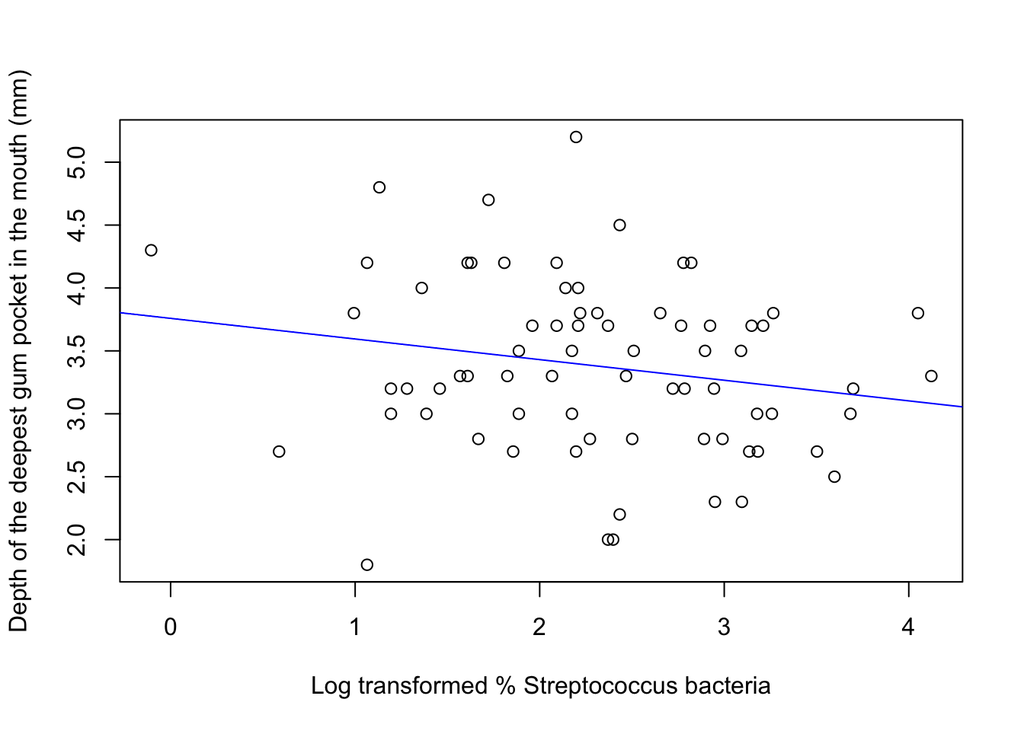

```r
#Strep vs. deepest
model3 <- lm(deepest ~ tstrep, data = perio) #create the linear model
plot(tstrep, perio$deepest,
     xlab = "Log transformed % Streptococcus bacteria",
     ylab = "Depth of the deepest gum pocket in the mouth (mm)") #create the plot
abline(model3, col = "blue") #adds a regression line to the plot
```

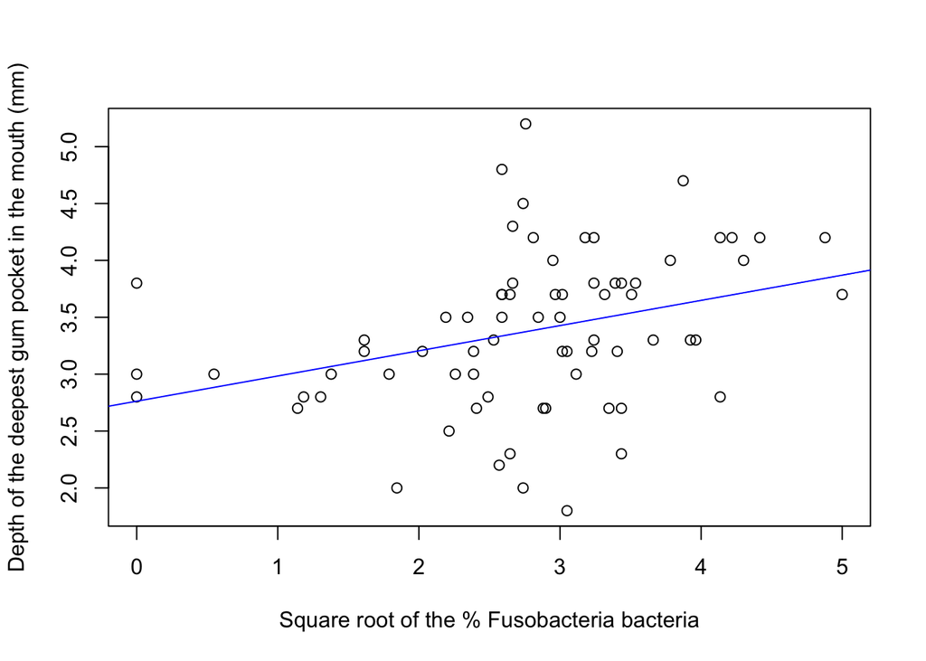

```r
#Fuso vs. deepest
model4 <- lm(deepest ~ tfuso, data = perio) #create the linear model
plot(tfuso, perio$deepest,
     xlab = "Square root of the % Fusobacteria bacteria",
     ylab = "Depth of the deepest gum pocket in the mouth (mm)") #create the plot
abline(model4, col = "blue") #adds a regression line to the plot
```

After conducting linear regressions looking at *Fusobacteria*, *Streptococcus* bacteria, and their relationship to the depth of the deepest gum pocket in the mount (mm), we can see that their is a slightly negative relationship between Streptococcus bacteria in the mouth and the depth of the gum pocket in the mouth, indicating that as the greater the gum pocket, the lower the % of the *Streptococcus* bacteria in the mouth. We can also see a slightly positive relationship between the amount of *Fusobacteria* bacteria present in the mouth and the depth of the gum pocket in the mouth, indicating that as the amount of fusobacteria increases, the deeper the depth of the gum pocket in the mouth.

## Part B: Use ggplot2 to make pretty graphs.

### ggplot histogram of prev variable

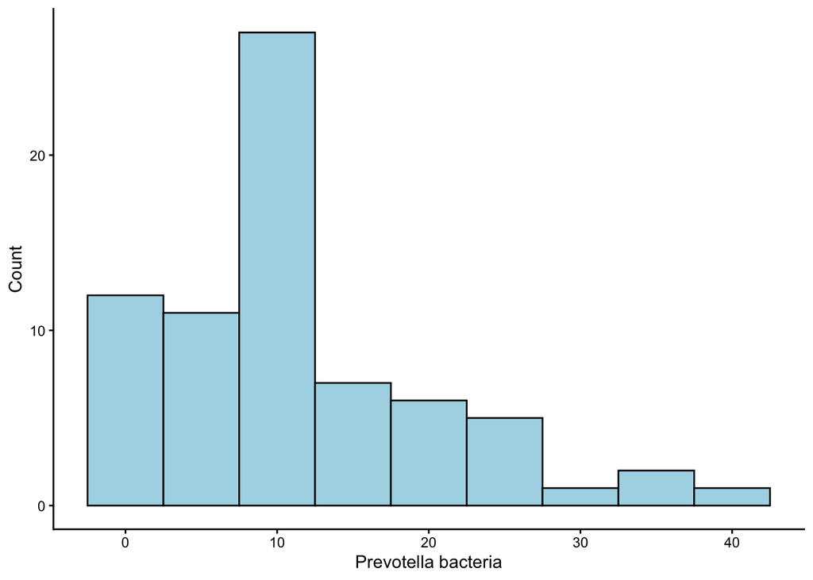

```r
prev_hist <- ggplot(data = perio, aes(x = prev)) + #assign the variable
  geom_histogram(binwidth = 5, color = "black", fill = "lightblue") + #create the histogram
  labs(x = "Prevotella bacteria",
       y = "Count") + #provide the labels
  theme_classic() #change the theme
prev_hist #print the plot
```

### ggplot scatterplot of strep by deepest, colored by time

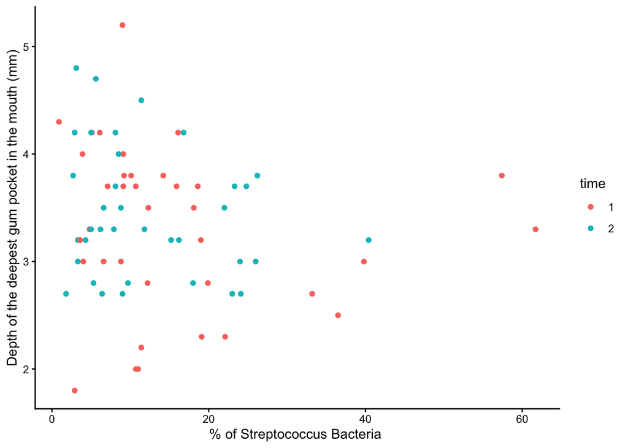

```r
perio$time <- as.factor(perio$time) #convert time into a factor
strep_deep_plot <- ggplot(data = perio, aes(x = strep, y = deepest, color = time)) + #assign the variables
  geom_point() + #create the scatter plot
  labs(x = "% of Streptococcus Bacteria ",
       y = "Depth of the deepest gum pocket in the mouth (mm)") +  #change the labels
  theme_classic() #change the theme
strep_deep_plot #print the plot
```

### ggplot scatterplot of fuso by deepest

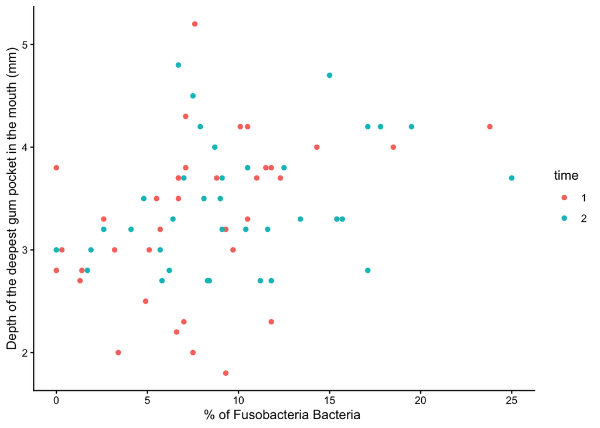

```r
fuso_deep_plot <- ggplot(data = perio, aes(x = fuso, y = deepest, color = time)) + #assign the variables
  geom_point() + #create the scatter plot
  labs(x = "% of Fusobacteria Bacteria ",
       y = "Depth of the deepest gum pocket in the mouth (mm)") +  #change the labels
  theme_classic() #change the theme
fuso_deep_plot #print the plot
```

### utilize the smoothing algorithm

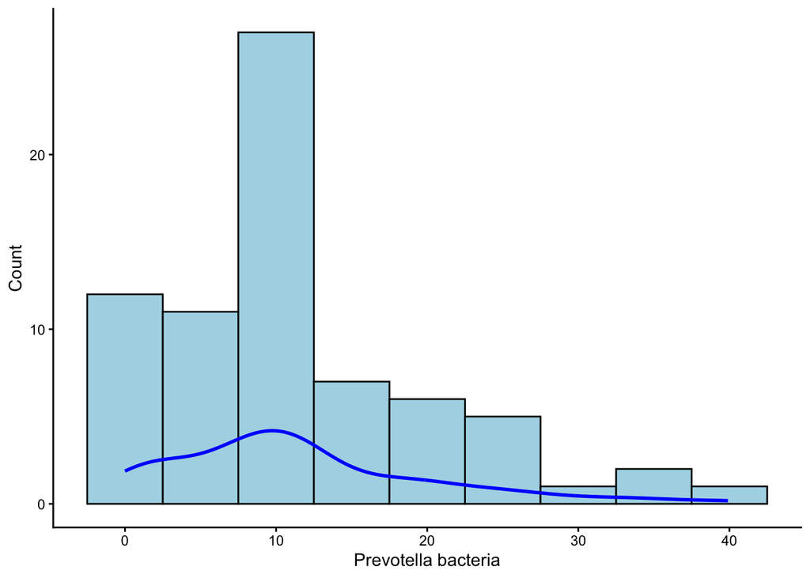

```r
prev_hist <- ggplot(data = perio, aes(x = prev)) + #assign the variable
  geom_histogram(binwidth = 5, color = "black", fill = "lightblue") + #create the histogram
  geom_density(aes(y = after_stat(count)), color = "blue", linewidth = 1) + #adds the smoothing algorithm
  labs(x = "Prevotella bacteria",
       y = "Count") + #provide the labels
  theme_classic() #change the theme
prev_hist #print the plot
```

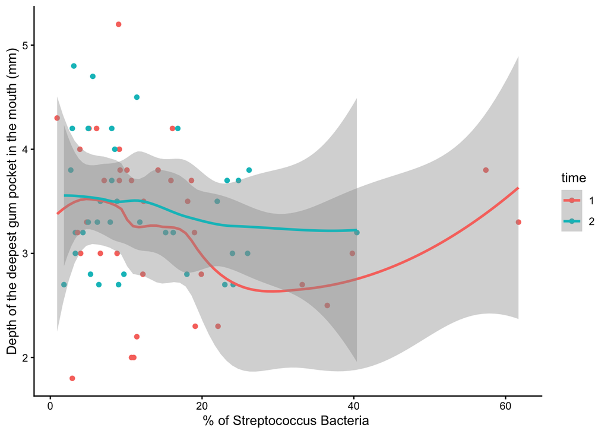

```r
strep_deep_plot <- ggplot(data = perio, aes(x = strep, y = deepest, color = time)) + #assign the variables
  geom_point() + #create the scatter plot
  geom_smooth() + #adds a regression line
  labs(x = "% of Streptococcus Bacteria ",
       y = "Depth of the deepest gum pocket in the mouth (mm)") +  #change the labels
  theme_classic() #change the theme
strep_deep_plot #print the plot
```

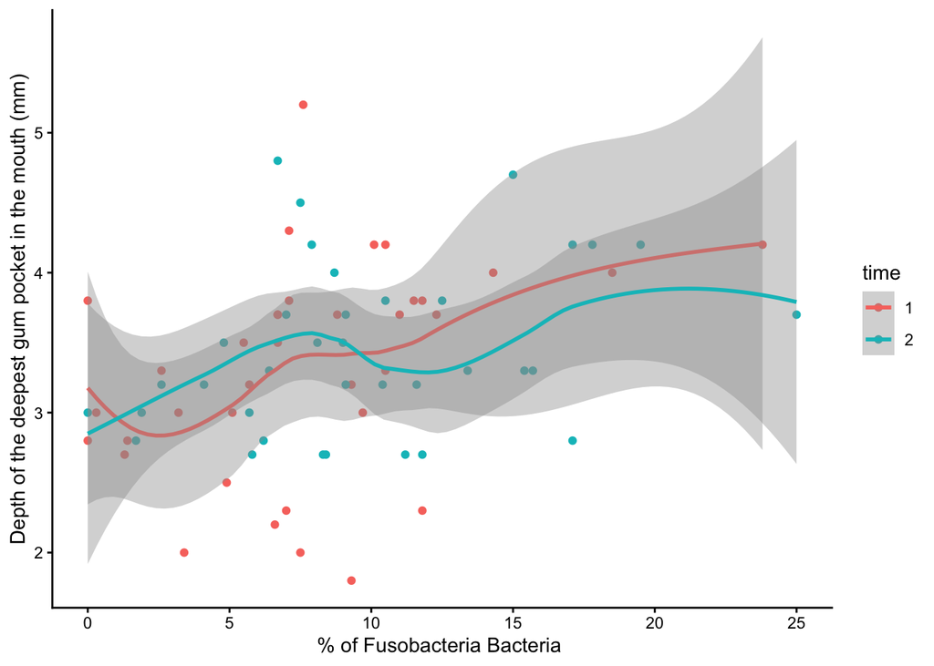

```r
fuso_deep_plot <- ggplot(data = perio, aes(x = fuso, y = deepest, color = time)) + #assign the variables
  geom_point() + #create the scatter plot
  geom_smooth() + #adds a regression line
  labs(x = "% of Fusobacteria Bacteria ",
       y = "Depth of the deepest gum pocket in the mouth (mm)") +  #change the labels
  theme_classic() #change the theme
fuso_deep_plot #print the plot
```